# Steelhead Overshoot Update

1/27/2022

## Overarching objective: Develop multidirectional model

## Focusing on river reaches rather than detection sites

- PIT tag arrays are used to determine transitions between “states,” where states are different river reaches, either in the mainstem of the Snake or Columbia Rivers, or in tributaries
- Movements between states can either be explicitly contained within the detection history (PIT tag array detections), or *implied* by the other detections in the detection history
  - This “implicit site usage” allows estimation of movement for the full, interpolated detection history, and thus multidirectional movement - more on this later

## Parameters at each state

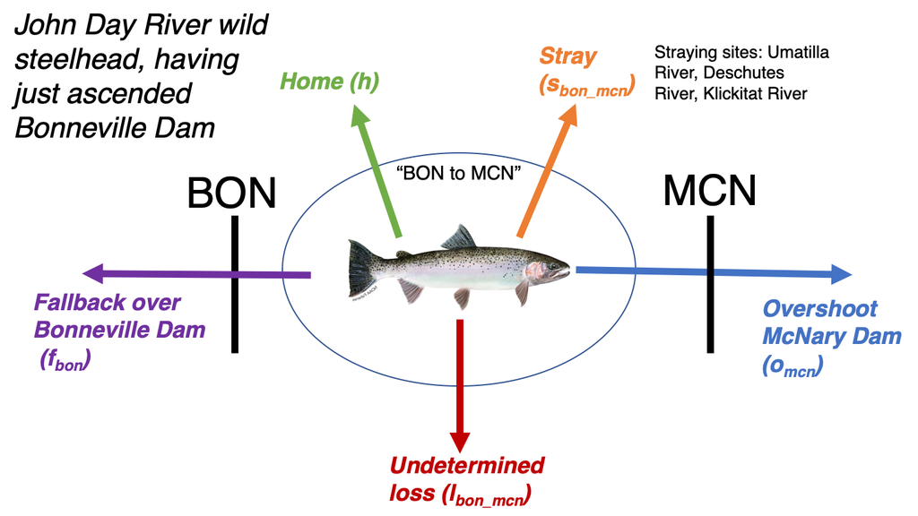

## Parameters overview

- Probabilties for an individual in the mainstem (sum to 1):
  - Overshoot the upstream dam (*o*)
  - Fallback over the downstream dam (*f*)
  - Stray to a non-natal tributary (*s*)
  - Home to natal tributaries (*h*) - only for individuals in the reach that connects to the natal tributary
  - Undetermined loss (*l*), when the detection history ends
- Probabilties for individuals in tributaries (sum to 1):
  - Undetermined loss (*l*) - end of detection history, likely indicates spawning
  - Return to mainstem (*r*)

## Complete parameterization

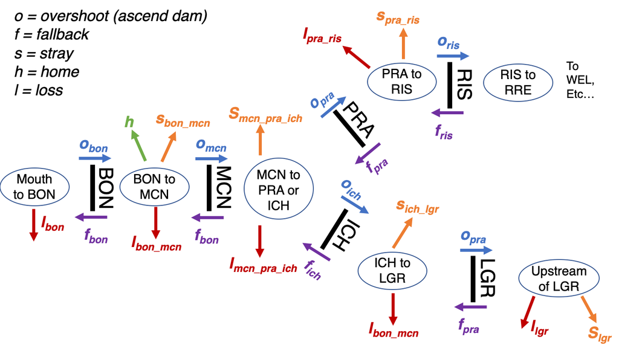

## Model structure

### What subscripts for each parameter?

- Run year
- Natal origin
- memory (of overshoot, fallback, tributary dip-ins)

### Implementation: Bayesian hierarchical?

- “Robin Hood” approach, where we can use information from more data-rich run years or natal origins to inform priors for data-poor run years or natal origins
  - Hierarchical modeling informed by biology

## Reformatting data for multidirectional model

## Distinguishing detection events

- Complete tag history (individual detections at arrays) queried from PTAGIS
- 6 hour cutoff used for separating events
- Exported file containing detections at individual sites, plus times of first and last times at the site for that detection

## Filling in missing movements

### Rules for determining “implicit site usage”:

- No teleporting - if two consecutive detections are in non-adjacent sites, the intermediate sites must be used
- For detections at adult fishways, the individual must have been in the downstream section previously
- For movement into/out of tributaries, the individual must have been in the corresponding section of the mainstem before/after
- For consecutive detections at dams, the individual must fall back in between

## Determining “implicit site usage”

```r
### Original detection history
subset(JDR_det_hist_forpres, tag_code == "3D9.1BF1989388") %>%
  remove_rownames() %>% dplyr::select(-c(tag_code, start_time))
```

```
##                        event_site_name            end_time
## 1 Bonneville Adult Fishways (combined) 2007-07-21 21:55:50
## 2     McNary Adult Fishways (combined) 2007-10-24 04:14:05
## 3     McNary Adult Fishways (combined) 2007-10-28 08:26:33
## 4 JD1 - John Day River, McDonald Ferry 2008-03-17 22:22:49
```

```r
### With implicit site usage
subset(JDR_states, tag_code == "3D9.1BF1989388") %>%
  remove_rownames() %>%
  dplyr::select(-c(tag_code, run_year))
```

```
##                         state           date_time             pathway
## 1        mainstem, BON to MCN 2007-07-21 21:55:50         BON (adult)
## 2 mainstem, MCN to ICH or PRA 2007-10-24 04:14:05         MCN (adult)
## 3        mainstem, BON to MCN                <NA>            implicit
## 4 mainstem, MCN to ICH or PRA 2007-10-28 08:26:33         MCN (adult)
## 5        mainstem, BON to MCN                <NA>            implicit
## 6           natal tributaries 2008-03-17 22:22:49 BON_MCN_natal_sites
```

## Turning this into model probabilities

```r
subset(JDR_stepwise_probabilities, tag_code == "3D9.1BF1989388") %>%
  dplyr::select(-c(tag_code,date_time_1,date_time_2, pathway))
```

```
##                        state_1                     state_2 probability
## 57        mainstem, BON to MCN mainstem, MCN to ICH or PRA       o_mcn
## 58 mainstem, MCN to ICH or PRA        mainstem, BON to MCN       f_mcn
## 59        mainstem, BON to MCN mainstem, MCN to ICH or PRA       o_mcn
## 60 mainstem, MCN to ICH or PRA        mainstem, BON to MCN       f_mcn
## 61        mainstem, BON to MCN           natal tributaries   h_bon_mcn
## 62           natal tributaries                        lost  l_nat_trib
```

For writing out a multinomial likelihood statement, the probability of this detection history is:

\[ {p} = {o_{mcn}f_{mcn}o_{mcn}f_{mcn}h_{bonmcn}l_{nattrib}} \] Concern: Technically infinite possible combinations of parameters (though in the data a finite number are realized). Buchanon (2005) got around this by modeling each detection history as only upstream movement, with fallback/downstream movement events having an effect on upstream movement.

## Accounting for repeat dam ascensions

1,118 of 2,121 John Day River wild steelhead overshot McNary Dam, and over a quarter of these individuals ascended McNary dam at least twice:

```r
kable(mcn_ascension_counts)
```

| MCN_ascensions | nIndividuals |
| --- | --- |
| 1 | 820 |
| 2 | 237 |
| 3 | 47 |
| 4 | 12 |
| 5 | 2 |

## Accounting for all fallback

```r
# Total individuals with known fallback over McNary
JDR_stepwise_probabilities %>% group_by(tag_code) %>%
  filter(any(probability == "f_mcn"))  -> mcn_fallback

length(unique(mcn_fallback$tag_code))
```

```
## [1] 649
```

```r
# Individuals that fell back, but did not home
JDR_stepwise_probabilities %>% group_by(tag_code) %>%
  filter(any(probability == "f_mcn")) %>%
  filter(!(any(probability == "h_bon_mcn"))) -> mcn_fallback_no_home

length(unique(mcn_fallback_no_home$tag_code))
```

```
## [1] 249
```

## Detection probabilities

Detection probabilities are no longer estimated in the model, since we have corrected for known missed detections. Instead, they can be calculated outside of the model as (detected + implicit) / total.

NOTE: This is an overestimate of detection probability, because of unknown missed detections (undetermined loss).

```r
# Example: Detection probability of fallback routes at McNary
JDR_stepwise_probabilities %>%
  subset(state_1 == "mainstem, MCN to ICH or PRA" &
           state_2 == "mainstem, BON to MCN") -> JDR_MCN_fallbacks
# Detection probability of fallback
length(subset(JDR_MCN_fallbacks, pathway ==
                "MCN_fallback_arrays")$tag_code)/
  length(JDR_MCN_fallbacks$tag_code)
```

```
## [1] 0.1264368
```

## Anomalous detection histories

## Iteroparous individuals

```r
subset(JDR_det_hist_forpres, tag_code == "3D9.1C2C31C103") %>%
  remove_rownames() %>%
  dplyr::select(-c(tag_code, start_time))
```

```
##                                event_site_name            end_time
## 1         Bonneville Adult Fishways (combined) 2010-07-26 04:38:05
## 2             McNary Adult Fishways (combined) 2010-09-05 07:00:58
## 3              ICH - Ice Harbor Dam (Combined) 2010-09-07 01:01:00
## 4  Lower Granite Dam Adult Fishways (combined) 2010-09-13 01:52:43
## 5                CATHEW - Catherine Creek Weir 2011-03-15 18:19:00
## 6         Bonneville Adult Fishways (combined) 2012-08-05 11:31:43
## 7         Bonneville Adult Fishways (combined) 2012-08-06 02:02:02
## 8             McNary Adult Fishways (combined) 2012-09-29 18:26:22
## 9              ICH - Ice Harbor Dam (Combined) 2012-10-02 00:43:34
## 10 Lower Granite Dam Adult Fishways (combined) 2012-10-07 07:30:10
## 11         UGR - Upper Grande Ronde at rkm 155 2013-02-22 19:36:04
## 12                    CATHEC - Catherine Creek 2013-03-10 18:45:00
## 13               CATHEW - Catherine Creek Weir 2013-03-12 05:18:00
## 14                    CATHEC - Catherine Creek 2013-03-31 18:47:00
## 15               CATHEW - Catherine Creek Weir 2013-03-31 20:45:00
## 16              BCC - BON PH2 Corner Collector 2013-06-03 13:47:35
```

## Tributary dip-ins at river mouths

[figure not shown]

## Confusing arrays

- “LGRTAL - LGR - Release into the Tailrace within 0.5 km downstream of Dam”
  - I took this to be a site just downstream of LGR
- “LGRLDR - LGR - Release into the Adult Fish Ladder”
  - I took this to be a detection site in the adult fish ladder for the dam
- The Dalles, Lower Monumental, and Lower Goose - adult fish ladder detections seen frequently in detection history, but in Richins and Skalski (2018) they said that no PIT tag arrays were present at these sites.